# Comparing means

Laboratory of Statistics and Mathematics 2025/2026

Giuseppe Alfonzetti

# Types of t-tests

- One-sample t-test : Compare one mean vs a known/target value
- Two-sample t-test: Compare means of two independent groups
- Paired t-test: Compare means on paired data (e.g. same people, before and after treatment)

# Case study A

- Your company is running a **marketing campaign** and you are monitoring the performance of the landing page in terms of *time-on-page* (i.e. seconds spent by the user on the landing page) to **assess its effectiveness**.
- Your direct competitor reached a time-on-page equal to $10$ seconds.
- You want to assess if your campaign performance is **significantly different** from your competitor benchmark.

# Data

```r
landing_data
```

```
# A tibble: 150 × 3
   user_id version           time_on_page
   <chr>   <chr>                    <dbl>
 1 user_2  standard_campaign        11.7
 2 user_6  standard_campaign         8.25
 3 user_7  standard_campaign         9.74
 4 user_8  standard_campaign        10.4
 5 user_10 standard_campaign         9.73
 6 user_11 standard_campaign         8.78
 7 user_13 standard_campaign         8.73
 8 user_15 standard_campaign        10.9
 9 user_16 standard_campaign         7.49
10 user_19 standard_campaign         9.81
# ℹ 140 more rows
```

# Plot

```r
landing_data |>
  ggplot(aes(x = version, y = time_on_page)) +
    geom_point() +
    labs(x="", y="Time on page (s)")
```

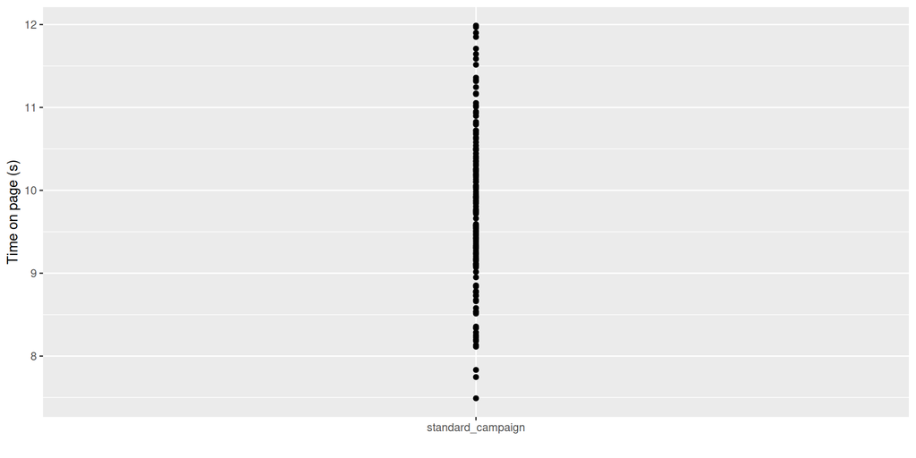

# Plot

```r
landing_data |>
  ggplot(aes(x = version, y = time_on_page)) +
    geom_point() +
    stat_summary(fun = "mean", geom = "point", size = 4, color="red")+
    labs(x="", y="Time on page (s)")
```

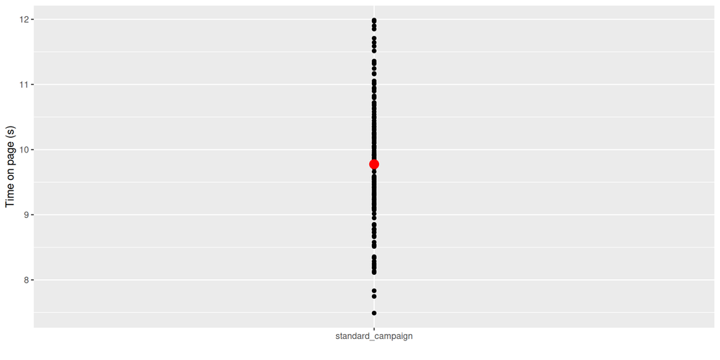

# Plot

```r
landing_data |>
  ggplot(aes(x = version, y = time_on_page)) +
    geom_boxplot() +
    labs(x="", y="Time on page (s)")
```

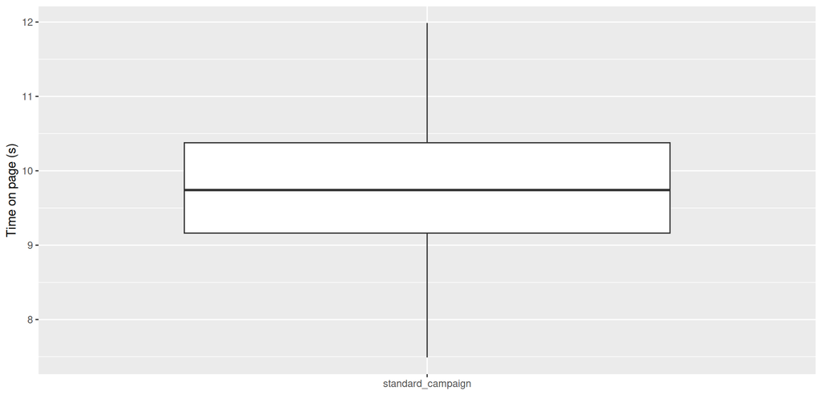

# Business question

Is the marketing campaign performing significantly different from the competitor benchmark, in terms of time-on-page?

```r
landing_data |>
  group_by(version) |>
  summarise(
    n = n(),
    mean_time = mean(time_on_page),
    sd_time = sd(time_on_page)
  )
```

```
# A tibble: 1 × 4
  version               n mean_time sd_time
  <chr>             <int>     <dbl>   <dbl>
1 standard_campaign   150      9.78   0.950
```

We can compare the average time-on-page to the benchmark with a t-test, using the `t.test()`function

```r
t.test(
  x=landing_data$time_on_page,
  mu=10,
  alternative = "two.sided"
  )
```

```
    One Sample t-test

data:  landing_data$time_on_page
t = -2.8933, df = 149, p-value = 0.004385
alternative hypothesis: true mean is not equal to 10
95 percent confidence interval:
 9.622404 9.928871
sample estimates:
mean of x
 9.775637
```

# Case study B

- You assessed that the data highlight a small underperformance of your company campaign compared to the competitor one.
- The design team provided you with an alternative version of the landing page.
- You are interested to check if the modified landing page performs differently from the old one.

# Case study B - Experiments

Now you can choose between:

- Bring to the new landing pege a *new sample of users* to monitor the **time-on-page**;
- Bring to the new landing page the *same users* who visited the old one.

In the first case, you can compare the average time-on-page of the standard and modified landing pages using a **Two sample t-test**. In the second case, you have to rely on a **Paired t-test**.

# Data

```r
modified_landing_data
```

```
# A tibble: 150 × 3
   user_id version           time_on_page
   <chr>   <chr>                    <dbl>
 1 user_1  modified_campaign        12.2
 2 user_3  modified_campaign        11.3
 3 user_4  modified_campaign        13.5
 4 user_5  modified_campaign        15.7
 5 user_9  modified_campaign        16.3
 6 user_12 modified_campaign         9.63
 7 user_14 modified_campaign        10.8
 8 user_17 modified_campaign        14.6
 9 user_18 modified_campaign        11.2
10 user_22 modified_campaign         9.73
# ℹ 140 more rows
```

```r
full_data <- landing_data |>
  bind_rows(modified_landing_data)
full_data
```

```
# A tibble: 300 × 3
   user_id version           time_on_page
   <chr>   <chr>                    <dbl>
 1 user_2  standard_campaign        11.7
 2 user_6  standard_campaign         8.25
 3 user_7  standard_campaign         9.74
 4 user_8  standard_campaign        10.4
 5 user_10 standard_campaign         9.73
 6 user_11 standard_campaign         8.78
 7 user_13 standard_campaign         8.73
 8 user_15 standard_campaign        10.9
 9 user_16 standard_campaign         7.49
10 user_19 standard_campaign         9.81
# ℹ 290 more rows
```

# Plot two groups

```r
full_data |>
  ggplot(aes(x = version, y = time_on_page)) +
    geom_boxplot() +
    labs(x="", y="Time to event (s)")
```

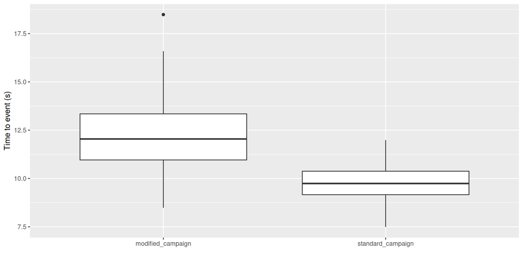

# Business question

Is the modified landing page performing significantly different from the old one, in terms of time-on-page?

```r
full_data |>
  group_by(version) |>
  summarise(
    n = n(),
    mean_time = mean(time_on_page),
    sd_time = sd(time_on_page)
  )
```

```
# A tibble: 2 × 4
  version               n mean_time sd_time
  <chr>             <int>     <dbl>   <dbl>
1 modified_campaign   150     12.2    1.88
2 standard_campaign   150      9.78   0.950
```

We can compare the average time-on-page between standard and modified landing pages, using the `t.test()`function

```r
t.test(time_on_page ~ version, data = full_data, paired=FALSE)
```

```
    Welch Two Sample t-test

data:  time_on_page by version
t = 14.003, df = 220.23, p-value < 2.2e-16
alternative hypothesis: true difference in means between group modified_campaign and group standard_campaign is not equal to 0
95 percent confidence interval:
 2.071554 2.750155
sample estimates:
mean in group modified_campaign mean in group standard_campaign
                      12.186491                        9.775637
```